[figure not shown]

# $K$-Means Clustering

Kannan Singaravelu

kannan.singaravelu@fitchlearning.com

# Clustering

Clustering is a branch of unsupervised machine learning models that seeks to learn from the properties of the data by identifying groups or clusters in the dataset. Clustering is different from classification as it seeks to identify a set of similar data points and calling the resulting set a cluster. Selecting an appropriate clustering algorithm is often difficult due to the number of choices available. For a comprehensive survey of clustering algorithms, refer [here](https://link.springer.com/content/pdf/10.1007/s40745-015-0040-1.pdf). The three most popular categories of clustering algorithms are

| Categories | Clustering Algorithm |
| --- | --- |
| Partitional clustering | divides data objects into non overlapping groups |
| Hierarchical clustering | assignments by building a hierarchy |
| Density-based clustering | assignments based on the density of data points in a region |

# $k$-Means Algorithm

The $k$-means algorithm searches for a predetermined number of clusters within an unlabeled dataset and is based on the assumptions that the optimal cluster will have

- *“cluster center” which is the mean of all the points belonging to the cluster.*
- *each point is closer to its own cluster center than to other cluster centers.*

Conventional $k$-means algorithm requires only a few steps and follows a two-step process called **Expectation-Maximization** approach. This consists of

1. Randomly selecting $k$-centroids or *cluster center*
2. Repeat until converged  
   a. *E-Step*: assign points to the nearest *cluster center*  
   b. *M-Step*: set the *cluster center* to the mean

The "E-Step" or "Expectation Step" assigns each data point to its nearest centroid. Then, the "M-Step" or Maximization Step" computes the mean of all the points for each cluster and sets the new centroid. The $k$-means algorithms seeks to find $k$ clusters within a data set. The clusters are chosen to reduce the **inertia**, the objective function

$$ \min_{C_k} \sum_{k} \sum_{X_j \in C_k} \| X_j - \mu_k \|^2. $$

and the centroid of a cluster $\mu_k$ is equal to

$$ \mu_k = \frac{1}{|C_k|} \sum_{X_j \in C_k} X_j, $$

where $|C_k|$ is the number of points in cluster $k$.

The cluster assignments are done based on squared Euclidean distance and algorithm tries to minimize the objective function. This process is repeated, iteratively, until the sum of the distance is minimized.

## Import Libraries

```python
# Base Libraries
import pandas as pd
import numpy as np
import missingno
import yfinance as yf

# Plotting
import matplotlib.pyplot as plt
plt.rcParams["figure.figsize"] = (10,6)

plt.style.use('fivethirtyeight')

# Ignore warnings
import warnings
warnings.filterwarnings('ignore')
```

```python
# Set display options
pd.set_option('display.max_rows', 5000)
pd.set_option('display.max_columns', 5000)
pd.set_option('display.width', 1000)
```

## Average True Range

Average True Range (ATR) is an indicator that measure volatility. It is calculated as the mean of the true range.

$TR = Max[(H-L), Abs(H-C_{prev}), Abs(L-C_{prev})] $

$ ATR = \frac{1}{n} \sum_{i=1}^n TR_i $

where, $TR_i$ is the true range of the period and $n$ is the time period

```python
# Function to calculate average true range
def ATR(dataframe, period=21):
    "function to calculate True Range and Average True Range"
    df = dataframe.copy()

    df['H-L']  = abs(df['High']-df['Low'])
    df['H-PC'] = abs(df['High']-df['Close'].shift(1))
    df['L-PC'] = abs(df['Low']-df['Close'].shift(1))

    df['TR']   = df[['H-L','H-PC','L-PC']].max(axis=1,skipna=False)
    df['ATR']  = df['TR'].rolling(period).mean()

    df = df.drop(['H-L','H-PC','L-PC'],axis=1,)
    return df['ATR']
```

```python
# Read components of dow from Yahoo Finance
dow = pd.read_html('https://en.wikipedia.org/wiki/Dow_Jones_Industrial_Average')
```

```python
# Retrieve components table
dow[1]
```

|  | Company | Exchange | Symbol | Industry | Date added | Notes | Index weighting |
| --- | --- | --- | --- | --- | --- | --- | --- |
| 0 | 3M | NYSE | MMM | Conglomerate | 1976-08-09 | As Minnesota Mining and Manufacturing | 3.62% |
| 1 | American Express | NYSE | AXP | Financial services | 1982-08-30 | NaN | 3.00% |
| 2 | Amgen | NASDAQ | AMGN | Pharmaceutical industry | 2020-08-31 | NaN | 4.18% |
| 3 | Apple Inc. | NASDAQ | AAPL | Information technology | 2015-03-19 | NaN | 2.78% |
| 4 | Boeing | NYSE | BA | Aerospace and defense | 1987-03-12 | NaN | 4.12% |
| 5 | Caterpillar Inc. | NYSE | CAT | Construction and Mining | 1991-05-06 | NaN | 3.96% |
| 6 | Chevron Corporation | NYSE | CVX | Petroleum industry | 2008-02-19 | Also 1930-07-18 to 1999-11-01 | 1.82% |
| 7 | Cisco Systems | NASDAQ | CSCO | Information technology | 2009-06-08 | NaN | 1.10% |
| 8 | The Coca-Cola Company | NYSE | KO | Food industry | 1987-03-12 | Also 1932-05-26 to 1935-11-20 | 1.04% |
| 9 | Dow Inc. | NYSE | DOW | Chemical industry | 2019-04-02 | NaN | 1.18% |
| 10 | Goldman Sachs | NYSE | GS | Financial services | 2013-09-20 | NaN | 7.60% |
| 11 | The Home Depot | NYSE | HD | Retailing | 1999-11-01 | NaN | 6.05% |
| 12 | Honeywell | NASDAQ | HON | Conglomerate | 2020-08-31 | NaN | 4.29% |
| 13 | IBM | NYSE | IBM | Information technology | 1979-06-29 | Also 1932-05-26 to 1939-03-04 | 2.60% |
| 14 | Intel | NASDAQ | INTC | Information technology | 1999-11-01 | NaN | 1.00% |
| 15 | Johnson & Johnson | NYSE | JNJ | Pharmaceutical industry | 1997-03-17 | NaN | 3.26% |
| 16 | JPMorgan Chase | NYSE | JPM | Financial services | 1991-05-06 | NaN | 2.93% |
| 17 | McDonald's | NYSE | MCD | Food industry | 1985-10-30 | NaN | 4.44% |
| 18 | Merck & Co. | NYSE | MRK | Pharmaceutical industry | 1979-06-29 | NaN | 1.45% |
| 19 | Microsoft | NASDAQ | MSFT | Information technology | 1999-11-01 | NaN | 5.63% |
| 20 | Nike, Inc. | NYSE | NKE | Apparel | 2013-09-20 | NaN | 3.16% |
| 21 | Procter & Gamble | NYSE | PG | Fast-moving consumer goods | 1932-05-26 | NaN | 2.66% |
| 22 | Salesforce | NYSE | CRM | Information technology | 2020-08-31 | NaN | 4.83% |
| 23 | The Travelers Companies | NYSE | TRV | Financial services | 2009-06-08 | NaN | 2.99% |
| 24 | UnitedHealth Group | NYSE | UNH | Managed health care | 2012-09-24 | NaN | 7.88% |
| 25 | Verizon Communications | NYSE | VZ | Telecommunication | 2004-04-08 | NaN | 1.02% |
| 26 | Visa Inc. | NYSE | V | Financial services | 2013-09-20 | NaN | 4.36% |
| 27 | Walgreens Boots Alliance | NASDAQ | WBA | Retailing | 2018-06-26 | NaN | 0.90% |
| 28 | Walmart | NYSE | WMT | Retailing | 1997-03-17 | NaN | 2.77% |
| 29 | The Walt Disney Company | NYSE | DIS | Broadcasting and entertainment | 1991-05-06 | NaN | 3.32% |

```python
# Retrieve stock symbol
dow_stocks = list(dow[1]['Symbol'])
dow_company_name = list(dow[1]['Company'])
dow_stocks[:5]
```

```
['MMM', 'AXP', 'AMGN', 'AAPL', 'BA']
```

```python
# Use comprehension to fetch data for multiple fields
# dow_ohlc = {symbol: yf.download(symbol, start='2010-01-01', end='2020-09-30', auto_adjust=True, progress=False) for symbol in dow_stocks}

# Save dow_ohlc dict for future use
# np.save('dow_ohlc.npy', dow_ohlc)
```

```python
# Load down_ohlc dict
ohlc = np.load('data/dow_ohlc.npy', allow_pickle='TRUE').item()
ohlc['MMM'].head()
```

| Date | Open | High | Low | Close | Volume |
| --- | --- | --- | --- | --- | --- |
| 2009-12-31 | 62.906018 | 63.123738 | 61.967570 | 62.065166 | 2049800 |
| 2010-01-04 | 62.380479 | 62.650753 | 62.065162 | 62.327927 | 3043700 |
| 2010-01-05 | 62.162779 | 62.485606 | 61.336941 | 61.937550 | 2847000 |
| 2010-01-06 | 62.973588 | 63.514135 | 62.695811 | 62.815929 | 5268500 |
| 2010-01-07 | 62.553137 | 62.883472 | 61.652230 | 62.860950 | 4470100 |

```python
for symbol in dow_stocks:
#     ohlc[symbol]['Intra'] = (ohlc[symbol]['Close']/ohlc[symbol]['Open'])-1
    ohlc[symbol]['ATR'] = ATR(ohlc[symbol])
```

## Daily Stock Price

```python
# Store stock prices in a dataframe
stock_price = pd.DataFrame({symbol: ohlc[symbol]['Close'] for symbol in dow_stocks})

# Check for missing values
stock_price.isnull().sum()
```

```
MMM        1
AXP        1
AMGN       1
AAPL       1
BA         1
CAT        1
CVX        1
CSCO       1
KO         1
DOW     2319
GS         1
HD         1
HON        1
IBM        1
INTC       1
JNJ        1
JPM        1
MCD        1
MRK        1
MSFT       1
NKE        1
PG         1
CRM        1
TRV        1
UNH        1
VZ         1
V          1
WBA        1
WMT        1
DIS        1
dtype: int64
```

```python
# Verify dataframe shape
stock_price.shape
```

```
(2706, 30)
```

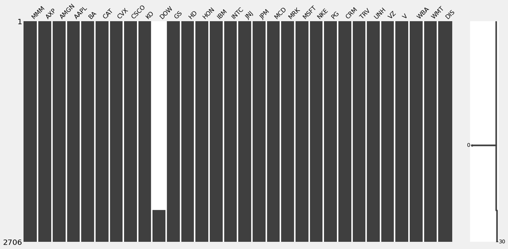

```python
# Alternatively use missingno library to verify missing values
missingno.matrix(stock_price, sparkline=True, figsize=(20,10));
```

```python
# Get the index of the NaN values
[stock_price[x].index[stock_price[x].apply(np.isnan)] for x in dow_stocks]
```

```
[DatetimeIndex(['2016-01-18'], dtype='datetime64[ns]', name='Date', freq=None),
 DatetimeIndex(['2016-01-18'], dtype='datetime64[ns]', name='Date', freq=None),
 DatetimeIndex(['2016-01-18'], dtype='datetime64[ns]', name='Date', freq=None),
 DatetimeIndex(['2016-01-18'], dtype='datetime64[ns]', name='Date', freq=None),
 DatetimeIndex(['2016-01-18'], dtype='datetime64[ns]', name='Date', freq=None),
 DatetimeIndex(['2016-01-18'], dtype='datetime64[ns]', name='Date', freq=None),
 DatetimeIndex(['2016-01-18'], dtype='datetime64[ns]', name='Date', freq=None),
 DatetimeIndex(['2016-01-18'], dtype='datetime64[ns]', name='Date', freq=None),
 DatetimeIndex(['2016-01-18'], dtype='datetime64[ns]', name='Date', freq=None),
 DatetimeIndex(['2009-12-31', '2010-01-04', '2010-01-05', '2010-01-06', '2010-01-07', '2010-01-08', '2010-01-11', '2010-01-12', '2010-01-13', '2010-01-14',
                ...
                '2019-03-06', '2019-03-07', '2019-03-08', '2019-03-11', '2019-03-12', '2019-03-13', '2019-03-14', '2019-03-15', '2019-03-18', '2019-03-19'], dtype='datetime64[ns]', name='Date', length=2319, freq=None),
 DatetimeIndex(['2016-01-18'], dtype='datetime64[ns]', name='Date', freq=None),
 DatetimeIndex(['2016-01-18'], dtype='datetime64[ns]', name='Date', freq=None),
 DatetimeIndex(['2016-01-18'], dtype='datetime64[ns]', name='Date', freq=None),
 DatetimeIndex(['2016-01-18'], dtype='datetime64[ns]', name='Date', freq=None),
 DatetimeIndex(['2016-01-18'], dtype='datetime64[ns]', name='Date', freq=None),
 DatetimeIndex(['2016-01-18'], dtype='datetime64[ns]', name='Date', freq=None),
 DatetimeIndex(['2016-01-18'], dtype='datetime64[ns]', name='Date', freq=None),
 DatetimeIndex(['2016-01-18'], dtype='datetime64[ns]', name='Date', freq=None),
 DatetimeIndex(['2016-01-18'], dtype='datetime64[ns]', name='Date', freq=None),
 DatetimeIndex(['2016-01-18'], dtype='datetime64[ns]', name='Date', freq=None),
 DatetimeIndex(['2016-01-18'], dtype='datetime64[ns]', name='Date', freq=None),
 DatetimeIndex(['2016-01-18'], dtype='datetime64[ns]', name='Date', freq=None),
 DatetimeIndex(['2016-01-18'], dtype='datetime64[ns]', name='Date', freq=None),
 DatetimeIndex(['2016-01-18'], dtype='datetime64[ns]', name='Date', freq=None),
 DatetimeIndex(['2016-01-18'], dtype='datetime64[ns]', name='Date', freq=None),
 DatetimeIndex(['2016-01-18'], dtype='datetime64[ns]', name='Date', freq=None),
 DatetimeIndex(['2016-01-18'], dtype='datetime64[ns]', name='Date', freq=None),
 DatetimeIndex(['2016-01-18'], dtype='datetime64[ns]', name='Date', freq=None),
 DatetimeIndex(['2016-01-18'], dtype='datetime64[ns]', name='Date', freq=None),
 DatetimeIndex(['2016-01-18'], dtype='datetime64[ns]', name='Date', freq=None)]
```

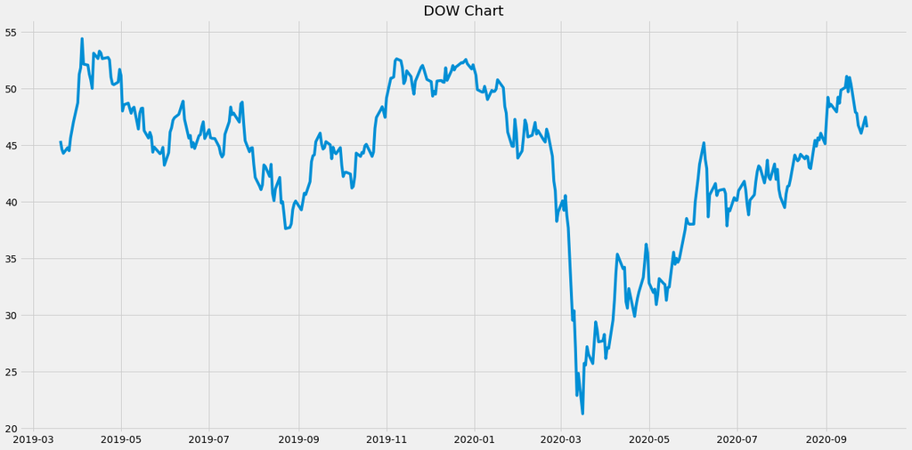

```python
# Plot to verify missing values
plt.figure(figsize=(20,10))
plt.plot(stock_price['DOW'])
plt.title('DOW Chart');
```

```python
# Fill forward the missing values and drop DOW form the list
stock_price.fillna(method='ffill', axis=0, inplace=True)
stock_price.drop(['DOW'], axis=1, inplace=True)
```

```python
stock_price.head()
```

| Date | MMM | AXP | AMGN | AAPL | BA | CAT | CVX | CSCO | KO | GS | HD | HON | IBM | INTC | JNJ | JPM | MCD | MRK | MSFT | NKE | PG | CRM | TRV | UNH | VZ | V | WBA | WMT | DIS |
| --- | --- | --- | --- | --- | --- | --- | --- | --- | --- | --- | --- | --- | --- | --- | --- | --- | --- | --- | --- | --- | --- | --- | --- | --- | --- | --- | --- | --- | --- |
| 2009-12-31 | 62.065166 | 34.434761 | 45.404182 | 6.503574 | 41.856789 | 41.498463 | 50.924435 | 18.048286 | 18.951757 | 144.296997 | 22.428135 | 29.058954 | 92.406113 | 14.717187 | 46.714996 | 31.395401 | 45.094296 | 25.193796 | 23.801456 | 12.066024 | 43.431492 | 18.442499 | 38.205708 | 25.778193 | 18.633041 | 17.935587 | 28.350834 | 40.954620 | 28.090706 |
| 2010-01-04 | 62.327927 | 34.774685 | 46.327202 | 6.604801 | 43.441975 | 42.634403 | 52.293617 | 18.613705 | 18.965061 | 147.920776 | 22.226564 | 29.911453 | 93.500313 | 15.063472 | 46.910812 | 32.323208 | 45.339836 | 25.517866 | 24.168472 | 11.934528 | 43.782478 | 18.705000 | 38.167397 | 26.666224 | 18.717409 | 18.075037 | 28.798639 | 41.552284 | 27.933924 |
| 2010-01-05 | 61.937550 | 34.698196 | 45.925884 | 6.616219 | 44.864773 | 43.144135 | 52.664024 | 18.530785 | 18.735643 | 150.535919 | 22.389368 | 29.970768 | 92.370834 | 15.056260 | 46.366856 | 32.949322 | 44.993195 | 25.621284 | 24.176279 | 11.982012 | 43.796806 | 18.625000 | 37.263195 | 26.623932 | 18.751152 | 17.867916 | 28.567017 | 41.138515 | 27.864237 |
| 2010-01-06 | 62.815929 | 35.259079 | 45.580757 | 6.510980 | 46.225727 | 43.275200 | 52.670624 | 18.410154 | 18.728989 | 148.929138 | 22.311846 | 29.970768 | 91.770790 | 15.005755 | 46.743999 | 33.130344 | 44.379295 | 25.966017 | 24.027906 | 11.908962 | 43.589062 | 18.592501 | 36.734470 | 26.886124 | 18.229431 | 17.627977 | 28.350834 | 41.046570 | 27.716166 |
| 2010-01-07 | 62.860950 | 35.830952 | 45.163395 | 6.498945 | 48.097031 | 43.449959 | 52.472206 | 18.493084 | 18.682440 | 151.843475 | 22.575434 | 30.548969 | 91.453102 | 14.861475 | 46.410374 | 33.786621 | 44.704296 | 26.007395 | 23.778025 | 12.025843 | 43.352684 | 18.510000 | 37.263195 | 27.917923 | 18.120922 | 17.792036 | 28.520689 | 41.069557 | 27.724878 |

```python
# Verify whether missing values are dropped
np.isnan(stock_price.any()).sum()
```

```
0
```

## Weekly Stock Price

```python
# Manipulate stock price dataframe: drop and resample
weekly_stock_price = stock_price.resample('W-FRI').last().pct_change()
weekly_stock_price = weekly_stock_price.T

# Check output
weekly_stock_price
```

| Date | 2010-01-01 | 2010-01-08 | 2010-01-15 | 2010-01-22 | 2010-01-29 | 2010-02-05 | 2010-02-12 | 2010-02-19 | 2010-02-26 | 2010-03-05 | 2010-03-12 | 2010-03-19 | 2010-03-26 | 2010-04-02 | 2010-04-09 | 2010-04-16 | 2010-04-23 | 2010-04-30 | 2010-05-07 | 2010-05-14 | 2010-05-21 | 2010-05-28 | 2010-06-04 | 2010-06-11 | 2010-06-18 | 2010-06-25 | 2010-07-02 | 2010-07-09 | 2010-07-16 | … |
| --- | --- | --- | --- | --- | --- | --- | --- | --- | --- | --- | --- | --- | --- | --- | --- | --- | --- | --- | --- | --- | --- | --- | --- | --- | --- | --- | --- | --- | --- | --- |
| MMM | NaN | 0.019959 | -0.011267 | -0.022669 | -0.012151 | -0.024226 | 0.008149 | 0.036314 | -0.016806 | 0.028571 | -0.012857 | 0.007127 | -0.011713 | 0.035185 | -0.004294 | 0.003234 | 0.033668 | 0.024140 | -0.068118 | 0.024810 | -0.041008 | -0.017224 | -0.040474 | 0.028909 | 0.036782 | -0.028086 | -0.015589 | 0.057809 | -0.014728 | … |
| AXP | NaN | 0.039802 | 0.010489 | -0.089644 | -0.024099 | 0.005045 | 0.015059 | 0.016658 | -0.022274 | 0.052632 | 0.013930 | -0.010549 | 0.019588 | 0.018525 | 0.052278 | 0.027803 | 0.065410 | -0.040167 | -0.119688 | 0.000985 | -0.020177 | 0.001256 | -0.036619 | 0.044780 | 0.047346 | 0.015227 | -0.071999 | 0.080163 | -0.028182 | … |
| AMGN | NaN | 0.003536 | -0.009160 | 0.006222 | 0.033215 | -0.013680 | -0.020804 | 0.015935 | -0.013419 | 0.011129 | 0.003319 | 0.044750 | -0.009833 | 0.023397 | 0.001645 | -0.002956 | -0.030303 | -0.026664 | -0.049730 | 0.004223 | -0.041141 | -0.012586 | 0.049440 | -0.004417 | 0.020333 | 0.019203 | -0.081052 | 0.016634 | -0.007420 | … |
| AAPL | NaN | 0.005932 | -0.028540 | -0.039722 | -0.028774 | 0.017703 | 0.025171 | 0.006438 | 0.014628 | 0.070032 | 0.034940 | -0.019197 | 0.038920 | 0.021958 | 0.024664 | 0.023202 | 0.094704 | -0.035963 | -0.096634 | 0.076147 | -0.045308 | 0.060086 | -0.003581 | -0.009572 | 0.081101 | -0.026891 | -0.074091 | 0.051349 | -0.037439 | … |
| BA | NaN | 0.138001 | -0.012662 | -0.050148 | 0.048987 | -0.029724 | 0.021404 | 0.066052 | -0.006762 | 0.075523 | 0.027970 | 0.012745 | 0.026442 | 0.005510 | -0.007809 | -0.022508 | 0.061308 | -0.035938 | -0.073489 | 0.046463 | -0.075337 | -0.005886 | -0.047211 | 0.069174 | 0.039462 | 0.011919 | -0.099317 | 0.043914 | -0.042685 | … |
| CAT | NaN | 0.058782 | 0.003152 | -0.097638 | -0.037051 | -0.009380 | 0.085990 | 0.036477 | -0.020601 | 0.038212 | 0.019078 | -0.016401 | 0.051709 | 0.024824 | 0.020003 | 0.024667 | 0.034824 | -0.010032 | -0.087972 | 0.044766 | -0.073828 | 0.011150 | -0.049375 | 0.042763 | 0.093309 | -0.017312 | -0.085458 | 0.093613 | -0.005473 | … |
| CVX | NaN | 0.032212 | -0.003020 | -0.058563 | -0.033114 | -0.013034 | 0.007160 | 0.042811 | -0.023633 | 0.027662 | -0.007806 | 0.017092 | -0.007335 | 0.030364 | 0.036641 | 0.015723 | 0.023777 | -0.014878 | -0.053291 | 0.009468 | -0.034107 | -0.008190 | -0.035062 | 0.039001 | 0.019714 | -0.072299 | -0.039252 | 0.067300 | -0.004733 | … |
| CSCO | NaN | 0.030075 | -0.010543 | -0.058606 | -0.021768 | 0.054740 | 0.002532 | 0.025252 | -0.001231 | 0.036169 | 0.026577 | 0.010433 | 0.012237 | -0.024178 | 0.029810 | 0.014286 | 0.018162 | -0.019658 | -0.082436 | 0.009308 | -0.059342 | -0.012788 | -0.008636 | -0.002178 | 0.025317 | -0.055768 | -0.047340 | 0.074302 | 0.002203 | … |
| KO | NaN | -0.032456 | 0.020671 | -0.036419 | 0.000185 | -0.021382 | 0.016764 | 0.032234 | -0.053841 | 0.037557 | -0.008583 | 0.026242 | -0.001826 | 0.011894 | -0.012839 | 0.006961 | -0.019829 | -0.007981 | -0.014593 | 0.012721 | -0.032808 | -0.003683 | -0.002529 | 0.024602 | 0.012778 | -0.039189 | -0.004178 | 0.046953 | -0.000572 | … |
| GS | NaN | 0.032398 | -0.052206 | -0.067127 | -0.035037 | 0.036579 | -0.001493 | 0.014617 | 0.003333 | 0.069268 | 0.046537 | 0.016804 | -0.028274 | -0.015330 | 0.052285 | -0.102836 | -0.020535 | -0.077510 | -0.015220 | 0.001679 | -0.018223 | 0.028451 | -0.013933 | -0.046467 | 0.018726 | 0.010711 | -0.061435 | 0.053250 | 0.058743 | … |
| HD | NaN | 0.001729 | -0.014148 | -0.029752 | 0.010462 | -0.001071 | 0.036455 | 0.039656 | 0.034826 | 0.019231 | 0.028040 | -0.002773 | 0.012052 | -0.011298 | 0.026869 | 0.052932 | 0.039417 | -0.031877 | -0.051093 | 0.052947 | -0.061932 | 0.025439 | -0.043831 | 0.002177 | -0.008691 | -0.054477 | -0.080795 | 0.018011 | -0.040694 | … |
| HON | NaN | 0.074490 | 0.012108 | -0.064509 | -0.031093 | -0.030280 | 0.010409 | 0.071066 | -0.001492 | 0.043576 | 0.024338 | 0.020732 | 0.017800 | 0.009641 | 0.016433 | 0.001093 | 0.041467 | -0.005239 | -0.083210 | 0.045037 | -0.068473 | 0.016639 | -0.039748 | 0.006087 | 0.038722 | -0.030755 | -0.073798 | 0.071114 | -0.026169 | … |
| IBM | NaN | -0.000382 | 0.007107 | -0.047655 | -0.024781 | 0.009233 | 0.008376 | 0.025726 | -0.000236 | 0.000708 | 0.005422 | -0.001798 | 0.012137 | -0.007814 | 0.003976 | 0.014524 | -0.004899 | -0.007616 | -0.048637 | 0.074447 | -0.043982 | -0.001275 | 0.000160 | 0.025303 | 0.013235 | -0.023281 | -0.041378 | 0.050058 | 0.000547 | … |
| INTC | NaN | 0.021079 | -0.001441 | -0.042788 | -0.025615 | 0.011637 | 0.049306 | 0.019090 | -0.013929 | 0.012664 | 0.023087 | 0.033851 | 0.011369 | 0.006744 | 0.007146 | 0.060754 | 0.005017 | -0.049917 | -0.060407 | 0.027217 | -0.044770 | 0.024390 | -0.021942 | -0.014798 | 0.036822 | -0.064019 | -0.041437 | 0.054166 | 0.038537 | … |
| JNJ | NaN | -0.003105 | 0.005451 | -0.021066 | -0.005380 | -0.003500 | 0.001277 | 0.025163 | -0.012694 | 0.016508 | 0.002186 | 0.014491 | -0.011212 | 0.021591 | -0.009579 | -0.001842 | 0.000308 | -0.011378 | -0.015397 | 0.010425 | -0.048304 | -0.033632 | -0.004974 | 0.007757 | 0.012316 | -0.008111 | 0.006473 | 0.024712 | -0.018170 | … |
| JPM | NaN | 0.073522 | -0.022381 | -0.103480 | -0.005618 | -0.016435 | 0.016971 | 0.027728 | 0.048463 | 0.020015 | 0.007942 | 0.006952 | 0.036134 | 0.004677 | 0.017707 | -0.009352 | -0.013392 | -0.052514 | -0.042743 | -0.021345 | 0.004011 | -0.011735 | -0.049520 | 0.012493 | 0.028616 | 0.006636 | -0.090289 | 0.084287 | 0.003861 | … |
| MCD | NaN | -0.009609 | 0.007115 | 0.017823 | -0.015144 | 0.015057 | 0.003472 | 0.018085 | -0.005365 | -0.002819 | 0.029214 | 0.015260 | 0.010973 | 0.004757 | 0.016277 | 0.005096 | 0.030712 | -0.007871 | -0.036549 | 0.023232 | -0.024860 | -0.006309 | -0.002542 | 0.042579 | 0.004889 | -0.035203 | -0.018986 | 0.046568 | 0.010401 | … |
| MRK | NaN | 0.031746 | 0.046950 | -0.015202 | -0.017751 | -0.037978 | 0.005173 | 0.015439 | -0.016271 | 0.016540 | 0.001577 | 0.024220 | -0.016553 | 0.007481 | -0.019624 | -0.034082 | -0.007001 | -0.011844 | -0.044235 | -0.018214 | -0.025547 | 0.051498 | -0.015435 | 0.062603 | 0.023235 | 0.007289 | -0.047592 | 0.060783 | -0.010744 | … |
| MSFT | NaN | 0.005906 | 0.006523 | -0.061568 | -0.026934 | -0.005678 | -0.003212 | 0.034892 | -0.003476 | -0.002790 | 0.023785 | 0.010932 | 0.002366 | -0.016858 | 0.040466 | 0.010877 | 0.009456 | -0.013566 | -0.076294 | 0.025523 | -0.068057 | -0.038748 | -0.000388 | -0.005041 | 0.030397 | -0.072239 | -0.051366 | 0.042974 | 0.025546 | … |
| NKE | NaN | -0.005298 | -0.020237 | -0.021898 | 0.012226 | -0.032157 | 0.012804 | 0.029765 | 0.050505 | 0.027049 | 0.023126 | 0.051788 | 0.005033 | 0.001624 | 0.015809 | -0.000133 | 0.036318 | -0.025545 | -0.069820 | 0.044328 | -0.031868 | 0.013867 | -0.007561 | 0.022043 | 0.036085 | -0.064318 | -0.032231 | 0.033746 | -0.016964 | … |
| PG | NaN | -0.003134 | 0.006287 | -0.001266 | 0.020561 | -0.004062 | 0.007504 | 0.027364 | -0.002679 | 0.006479 | -0.005809 | 0.008212 | -0.002350 | -0.005181 | -0.009943 | 0.001913 | 0.010979 | -0.014192 | -0.029762 | 0.036975 | -0.011032 | -0.012288 | -0.004747 | 0.003454 | 0.004754 | -0.024633 | -0.006857 | 0.039912 | 0.003887 | … |
| CRM | NaN | 0.005151 | -0.074444 | -0.059595 | -0.015339 | -0.023131 | 0.048486 | 0.058842 | -0.014074 | 0.063723 | 0.047454 | 0.004095 | -0.014075 | 0.007872 | 0.055997 | 0.046509 | 0.056061 | -0.029038 | -0.094393 | 0.092879 | -0.017469 | 0.039524 | 0.035941 | 0.078090 | -0.009520 | -0.042833 | -0.049225 | 0.053610 | 0.002942 | … |
| TRV | NaN | -0.026073 | 0.004736 | -0.009839 | 0.048852 | -0.007697 | 0.003381 | 0.048167 | -0.005484 | 0.025671 | -0.008394 | 0.005644 | 0.016648 | -0.007912 | -0.028190 | -0.004962 | 0.023782 | -0.049456 | -0.029169 | 0.017458 | -0.017757 | 0.004875 | -0.017384 | 0.044822 | 0.018647 | -0.004479 | -0.050470 | 0.053771 | -0.029912 | … |
| UNH | NaN | 0.072835 | 0.032110 | -0.017481 | -0.004825 | -0.013939 | -0.011063 | -0.007458 | 0.060113 | -0.003544 | -0.024600 | 0.044971 | -0.051177 | 0.011961 | -0.022127 | -0.047427 | 0.007159 | -0.020679 | -0.042560 | 0.047209 | -0.055610 | 0.012892 | 0.048068 | 0.010877 | 0.021519 | -0.046282 | -0.052878 | 0.059011 | 0.012346 | … |
| VZ | NaN | -0.026871 | -0.036850 | -0.007848 | -0.030323 | -0.023113 | 0.006611 | 0.003111 | -0.003101 | 0.010370 | 0.017106 | 0.022872 | -0.001316 | 0.029964 | -0.022495 | -0.016622 | -0.017918 | -0.005163 | -0.024567 | 0.011351 | -0.019291 | -0.015736 | -0.011265 | 0.049614 | 0.019958 | -0.019911 | 0.001242 | 0.012099 | 0.001501 | … |
| V | NaN | -0.005260 | -0.009885 | -0.039587 | -0.008461 | 0.006461 | 0.033093 | 0.023945 | -0.017625 | 0.037875 | 0.053553 | -0.047292 | 0.015872 | 0.025485 | -0.000324 | 0.014375 | 0.029195 | -0.065845 | -0.087997 | -0.055514 | -0.039606 | -0.023450 | -0.004554 | 0.054762 | 0.012618 | -0.004932 | -0.045395 | 0.057392 | -0.076635 | … |
| WBA | NaN | 0.007353 | -0.010544 | -0.016666 | 0.001667 | -0.076005 | 0.005404 | 0.045215 | 0.010901 | -0.007094 | -0.030294 | 0.017683 | 0.065451 | 0.026094 | -0.018014 | -0.032641 | 0.000000 | -0.019799 | -0.007965 | 0.014626 | -0.060814 | -0.032024 | -0.037453 | -0.044099 | 0.020692 | -0.105018 | -0.021166 | 0.077390 | 0.028521 | … |
| WMT | NaN | -0.002245 | 0.006563 | -0.013786 | 0.009256 | 0.000374 | -0.010290 | 0.011153 | 0.010843 | 0.001295 | 0.001169 | 0.026716 | 0.003072 | -0.000360 | -0.007569 | -0.017433 | 0.007762 | -0.016321 | -0.023117 | 0.000425 | -0.014390 | -0.015768 | -0.003165 | 0.009127 | 0.013567 | -0.053346 | -0.016394 | 0.029792 | 0.004855 | … |
| DIS | NaN | -0.011473 | -0.040150 | -0.020261 | -0.014343 | -0.000338 | 0.017942 | 0.038577 | 0.000320 | 0.063381 | 0.014148 | -0.001484 | 0.049643 | 0.006797 | 0.018847 | -0.010768 | 0.026793 | 0.001359 | -0.093106 | 0.019455 | -0.034938 | 0.016733 | 0.008079 | 0.016325 | 0.026577 | -0.047511 | -0.062724 | 0.075526 | -0.021333 | … |

## Daily Stock ATR

```python
# Add ATR to each stocks
stock_atr = pd.DataFrame({symbol: ohlc[symbol]['ATR'] for symbol in dow_stocks})
```

```python
# Check for missing values
stock_atr.isnull().sum()
```

```
MMM       22
AXP       22
AMGN      22
AAPL      22
BA        22
CAT       43
CVX       22
CSCO      22
KO        22
DOW     2340
GS        22
HD        22
HON       22
IBM       22
INTC      22
JNJ       22
JPM       22
MCD       22
MRK       22
MSFT      22
NKE       22
PG        22
CRM       22
TRV       22
UNH       22
VZ        22
V         22
WBA       22
WMT       22
DIS       22
dtype: int64
```

```python
# Fill backward the missing values and drop DOW form the list
stock_atr.fillna(method='bfill', axis=0, inplace=True)
stock_atr.drop(['DOW'], axis=1, inplace=True)
```

## Weekly ATR

```python
# Manipulate dataframe: drop and resample
weekly_atr = stock_atr.resample('W-FRI').last()
weekly_atr = weekly_atr.T

# Check output
weekly_atr.head()
```

| Date | 2010-01-01 | 2010-01-08 | 2010-01-15 | 2010-01-22 | 2010-01-29 | 2010-02-05 | 2010-02-12 | 2010-02-19 | 2010-02-26 | 2010-03-05 | 2010-03-12 | 2010-03-19 | 2010-03-26 | 2010-04-02 | 2010-04-09 | 2010-04-16 | 2010-04-23 | 2010-04-30 | 2010-05-07 | 2010-05-14 | 2010-05-21 | 2010-05-28 | 2010-06-04 | 2010-06-11 | 2010-06-18 | 2010-06-25 | 2010-07-02 | 2010-07-09 | 2010-07-16 | … |
| --- | --- | --- | --- | --- | --- | --- | --- | --- | --- | --- | --- | --- | --- | --- | --- | --- | --- | --- | --- | --- | --- | --- | --- | --- | --- | --- | --- | --- | --- | --- |
| MMM | 1.113625 | 1.113625 | 1.113625 | 1.113625 | 1.113625 | 1.197639 | 1.297385 | 1.283478 | 1.205613 | 1.042977 | 0.898715 | 0.882357 | 0.831977 | 0.908265 | 0.881277 | 0.935614 | 0.915462 | 0.971238 | 1.885983 | 2.071305 | 2.234689 | 2.314800 | 2.346818 | 1.596086 | 1.533916 | 1.449183 | 1.394141 | 1.337290 | 1.294921 | … |
| AXP | 1.035185 | 1.035185 | 1.035185 | 1.035185 | 1.035185 | 1.072190 | 1.094950 | 1.081132 | 0.845803 | 0.784837 | 0.699078 | 0.660873 | 0.677536 | 0.674609 | 0.732077 | 0.835600 | 0.959207 | 1.120132 | 1.405880 | 1.622233 | 1.766740 | 1.746330 | 1.717348 | 1.480992 | 1.299746 | 1.208307 | 1.172241 | 1.134881 | 1.148018 | … |
| AMGN | 0.944033 | 0.944033 | 0.944033 | 0.944033 | 0.944033 | 0.945562 | 0.863389 | 0.806823 | 0.733058 | 0.706305 | 0.567949 | 0.679169 | 0.691400 | 0.715096 | 0.705541 | 0.719301 | 0.760579 | 0.827081 | 1.022004 | 1.181381 | 1.208516 | 1.292601 | 1.466502 | 1.242915 | 1.191700 | 1.148129 | 1.040348 | 1.044170 | 1.028500 | … |
| AAPL | 0.189773 | 0.189773 | 0.189773 | 0.189773 | 0.189773 | 0.201530 | 0.202220 | 0.186275 | 0.151460 | 0.131811 | 0.122126 | 0.117482 | 0.120230 | 0.124815 | 0.114513 | 0.114587 | 0.150901 | 0.178207 | 0.306035 | 0.365466 | 0.372668 | 0.383602 | 0.370742 | 0.262401 | 0.242135 | 0.213566 | 0.231201 | 0.223677 | 0.232994 | … |
| BA | 1.420966 | 1.420966 | 1.420966 | 1.420966 | 1.420966 | 1.389642 | 1.371846 | 1.382832 | 1.237241 | 1.220088 | 1.128888 | 1.148537 | 1.115170 | 1.175231 | 1.106644 | 1.125181 | 1.127406 | 1.211932 | 1.665545 | 1.992950 | 2.185258 | 2.268326 | 2.298844 | 1.836467 | 1.672769 | 1.515410 | 1.550834 | 1.515783 | 1.448663 | … |

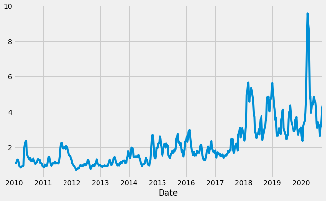

```python
# Plot weekly atr values for MMM
weekly_atr.iloc[0,:].plot()
```

```python
# Summary statistics
weekly_atr.T.describe()
```

|  | MMM | AXP | AMGN | AAPL | BA | CAT | CVX | CSCO | KO | GS | HD | HON | IBM | INTC | JNJ | JPM | MCD | MRK | MSFT | NKE | PG | CRM | TRV | UNH | VZ | V | WBA | WMT | DIS |
| --- | --- | --- | --- | --- | --- | --- | --- | --- | --- | --- | --- | --- | --- | --- | --- | --- | --- | --- | --- | --- | --- | --- | --- | --- | --- | --- | --- | --- | --- |
| count | 562.000000 | 562.000000 | 562.000000 | 562.000000 | 562.000000 | 562.000000 | 562.000000 | 562.000000 | 562.000000 | 562.000000 | 562.000000 | 562.000000 | 562.000000 | 562.000000 | 562.000000 | 562.000000 | 562.000000 | 562.000000 | 562.000000 | 562.000000 | 562.000000 | 562.000000 | 562.000000 | 562.000000 | 562.000000 | 562.000000 | 562.000000 | 562.000000 | 562.000000 |
| mean | 2.101351 | 1.427355 | 2.670555 | 0.683054 | 3.781579 | 2.079727 | 1.632494 | 0.542990 | 0.493957 | 3.637879 | 1.987204 | 1.611824 | 2.094200 | 0.700276 | 1.307901 | 1.311930 | 1.650879 | 0.865587 | 1.297601 | 0.973594 | 1.033288 | 2.206371 | 1.425766 | 2.749258 | 0.605954 | 1.505029 | 1.120467 | 1.120372 | 1.485320 |
| std | 1.274418 | 1.051843 | 1.808259 | 0.780019 | 3.848042 | 1.177531 | 0.827709 | 0.365297 | 0.328816 | 1.597319 | 2.006454 | 1.345810 | 0.797313 | 0.552347 | 0.943878 | 1.002071 | 1.488659 | 0.530321 | 1.542003 | 0.839399 | 0.791584 | 1.864154 | 0.994521 | 2.861084 | 0.307329 | 1.617437 | 0.512961 | 0.821365 | 1.063673 |
| min | 0.691366 | 0.606557 | 0.567949 | 0.097759 | 0.746846 | 0.722254 | 0.614034 | 0.194218 | 0.195102 | 1.663223 | 0.335078 | 0.498264 | 0.941092 | 0.180611 | 0.374586 | 0.531315 | 0.486011 | 0.289577 | 0.279985 | 0.189408 | 0.403087 | 0.387976 | 0.484676 | 0.524968 | 0.179760 | 0.232951 | 0.384447 | 0.391442 | 0.423480 |
| 25% | 1.163486 | 0.918648 | 1.169537 | 0.302438 | 1.364933 | 1.315786 | 1.143003 | 0.323853 | 0.334156 | 2.609529 | 0.797480 | 0.867383 | 1.589712 | 0.373841 | 0.723857 | 0.757473 | 0.842875 | 0.533932 | 0.497261 | 0.435064 | 0.653418 | 1.162113 | 0.811880 | 0.993601 | 0.424196 | 0.558725 | 0.713803 | 0.680728 | 0.805065 |
| 50% | 1.684730 | 1.108258 | 2.460567 | 0.438350 | 2.058173 | 1.650134 | 1.405017 | 0.406443 | 0.416208 | 3.312937 | 1.453257 | 1.220924 | 1.926260 | 0.492529 | 1.054667 | 0.998494 | 1.200275 | 0.733529 | 0.740575 | 0.759029 | 0.830247 | 1.520119 | 1.156166 | 1.805687 | 0.548817 | 0.992201 | 1.072514 | 0.885314 | 1.210363 |
| 75% | 2.669524 | 1.553590 | 3.328353 | 0.697049 | 5.792889 | 2.416902 | 1.912475 | 0.666026 | 0.538360 | 4.097964 | 2.589712 | 1.789246 | 2.366806 | 0.860891 | 1.586287 | 1.511916 | 1.995181 | 1.024279 | 1.364529 | 1.277629 | 1.088584 | 2.581310 | 1.697279 | 3.368308 | 0.703961 | 1.818519 | 1.403106 | 1.245846 | 1.824364 |
| max | 9.576975 | 10.056823 | 13.974501 | 6.072857 | 25.925239 | 8.728654 | 7.895263 | 2.936952 | 3.405267 | 15.186361 | 17.718777 | 12.713375 | 8.030972 | 4.621850 | 8.122117 | 9.366074 | 14.604702 | 4.610155 | 11.612370 | 7.227349 | 8.103057 | 13.027620 | 9.116375 | 23.589189 | 3.164337 | 13.307093 | 3.996797 | 7.523459 | 9.061905 |

## Elbow Plot

The number of clusters is a hyperparameter to clustering models and choose the optimal number of clusters is critical for the model. If every point is its own cluster, the inertia is zero and hence choosing the number of clusters that yields the lowest results in not appropriate. Instead, we need to identify the inflection point where increasing the number of clusters no longer result in significant drop in inertia. Elbow plot helps us to select the optimal number of clusters.

```python
# Import sklearn modules
from sklearn.preprocessing import MinMaxScaler
from sklearn.model_selection import train_test_split
from sklearn.cluster import KMeans
from sklearn.pipeline import Pipeline

# import yfinance as yf
from datetime import datetime
```

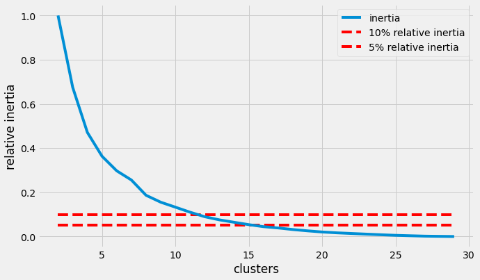

```python
n_clusters = range(2, 30)
inertia = []

for n in n_clusters:
    kmeans = KMeans(n_clusters=n)
    kmeans.fit(weekly_atr)
    inertia.append(kmeans.inertia_)

plt.plot(n_clusters, np.divide(inertia,inertia[0]))
plt.hlines(0.1, n_clusters[0], n_clusters[-1], 'r', linestyles='dashed')
plt.hlines(0.05, n_clusters[0], n_clusters[-1], 'r', linestyles='dashed')
plt.xlabel('clusters')
plt.ylabel('relative inertia')
plt.legend(['inertia', '10% relative inertia', '5% relative inertia']);
```

Silhouette Coefficient is another metric measure of how dense and separated are the clusters. Silhouette coefficient values range between -1 and 1. Larger numbers indicate that samples are closer to their clusters than they are to other clusters. Silhouette coefficient implementation is straight forward where the average silhouette coefficient of all the samples is summarized into one score. The `silhouette_score` function needs a minimum of two clusters, or it will raise an exception.

## Build Clusters

```python
# Normalize and fit the model
pipe = Pipeline([("normalization", MinMaxScaler()), ("cluster", KMeans(n_clusters=15))])
```

```python
# Fit Model
pipe.fit(weekly_atr)

# Assign Label
labels = pipe.predict(weekly_atr)
```

```python
# Check lables
labels
```

```
array([ 8, 13,  5, 11,  6,  2, 12, 11, 11,  3, 14, 13, 10, 11, 13, 13, 13,
        0,  4,  0,  0,  9, 13,  1, 11,  4,  7,  0,  7], dtype=int32)
```

```python
# Check average weekly stock price
weekly_stock_price.mean(axis=1)
```

```
MMM     0.002096
AXP     0.002617
AMGN    0.003558
AAPL    0.005884
BA      0.004052
CAT     0.003068
CVX     0.001211
CSCO    0.001977
KO      0.002008
GS      0.001351
HD      0.005014
HON     0.003627
IBM     0.000940
INTC    0.002865
JNJ     0.002280
JPM     0.002658
MCD     0.003108
MRK     0.002460
MSFT    0.004348
NKE     0.004777
PG      0.002292
CRM     0.005697
TRV     0.002259
UNH     0.005033
VZ      0.002339
V       0.004790
WBA     0.001044
WMT     0.002466
DIS     0.003183
dtype: float64
```

```python
# Remove DOW from the list
companies = dow_stocks
companies.remove('DOW')

# Remove Dow Inc from the compnay name
companies_name = dow_company_name
companies_name.remove('Dow Inc.')
```

```python
# Create dataframe to hold cluster details
df = pd.DataFrame({'Cluster': labels,
                    'Companies Name': companies_name,
                    'Companies': companies,
                    'ATR': weekly_atr.mean(axis=1),
                    'CHG': weekly_stock_price.mean(axis=1)}
                  ).sort_values(by=['Cluster'], axis = 0)

df = df.reset_index(drop=True)
df
```

|  | Cluster | Companies Name | Companies | ATR | CHG |
| --- | --- | --- | --- | --- | --- |
| 0 | 0 | Procter & Gamble | PG | 1.033288 | 0.002292 |
| 1 | 0 | Nike, Inc. | NKE | 0.973594 | 0.004777 |
| 2 | 0 | Merck & Co. | MRK | 0.865587 | 0.002460 |
| 3 | 0 | Walmart | WMT | 1.120372 | 0.002466 |
| 4 | 1 | UnitedHealth Group | UNH | 2.749258 | 0.005033 |
| 5 | 2 | Caterpillar Inc. | CAT | 2.079727 | 0.003068 |
| 6 | 3 | Goldman Sachs | GS | 3.637879 | 0.001351 |
| 7 | 4 | Visa Inc. | V | 1.505029 | 0.004790 |
| 8 | 4 | Microsoft | MSFT | 1.297601 | 0.004348 |
| 9 | 5 | Amgen | AMGN | 2.670555 | 0.003558 |
| 10 | 6 | Boeing | BA | 3.781579 | 0.004052 |
| 11 | 7 | The Walt Disney Company | DIS | 1.485320 | 0.003183 |
| 12 | 7 | Walgreens Boots Alliance | WBA | 1.120467 | 0.001044 |
| 13 | 8 | 3M | MMM | 2.101351 | 0.002096 |
| 14 | 9 | Salesforce | CRM | 2.206371 | 0.005697 |
| 15 | 10 | IBM | IBM | 2.094200 | 0.000940 |
| 16 | 11 | The Coca-Cola Company | KO | 0.493957 | 0.002008 |
| 17 | 11 | Cisco Systems | CSCO | 0.542990 | 0.001977 |
| 18 | 11 | Verizon Communications | VZ | 0.605954 | 0.002339 |
| 19 | 11 | Apple Inc. | AAPL | 0.683054 | 0.005884 |
| 20 | 11 | Intel | INTC | 0.700276 | 0.002865 |
| 21 | 12 | Chevron Corporation | CVX | 1.632494 | 0.001211 |
| 22 | 13 | JPMorgan Chase | JPM | 1.311930 | 0.002658 |
| 23 | 13 | McDonald's | MCD | 1.650879 | 0.003108 |
| 24 | 13 | Honeywell | HON | 1.611824 | 0.003627 |
| 25 | 13 | The Travelers Companies | TRV | 1.425766 | 0.002259 |
| 26 | 13 | American Express | AXP | 1.427355 | 0.002617 |
| 27 | 13 | Johnson & Johnson | JNJ | 1.307901 | 0.002280 |
| 28 | 14 | The Home Depot | HD | 1.987204 | 0.005014 |

Thus, using k-means, we have discovered companies that exhibit similar volatility characteristics as measured by the Average True Range (ATR).

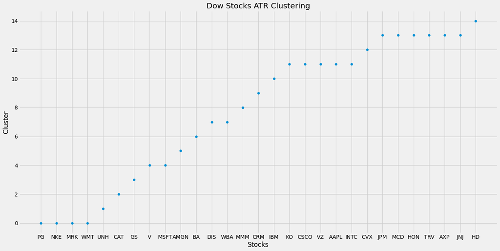

```python
plt.figure(figsize=(20,10))
plt.scatter(df.Companies, df.Cluster)
plt.xlabel('Stocks')
plt.ylabel('Cluster')
plt.title('Dow Stocks ATR Clustering');
```

```python
pipe.get_params()
```

```
{'memory': None,
 'steps': [('normalization', MinMaxScaler()),
  ('cluster', KMeans(n_clusters=15))],
 'verbose': False,
 'normalization': MinMaxScaler(),
 'cluster': KMeans(n_clusters=15),
 'normalization__clip': False,
 'normalization__copy': True,
 'normalization__feature_range': (0, 1),
 'cluster__algorithm': 'auto',
 'cluster__copy_x': True,
 'cluster__init': 'k-means++',
 'cluster__max_iter': 300,
 'cluster__n_clusters': 15,
 'cluster__n_init': 10,
 'cluster__n_jobs': 'deprecated',
 'cluster__precompute_distances': 'deprecated',
 'cluster__random_state': None,
 'cluster__tol': 0.0001,
 'cluster__verbose': 0}
```

```python
pipe['cluster'].cluster_centers_
```

```
array([[0.08913467, 0.08913467, 0.08913467, ..., 0.15546854, 0.21474744,
        0.22039994],
       [0.18259778, 0.18259778, 0.18259778, ..., 0.55527179, 0.72425244,
        0.76526999],
       [0.31915147, 0.31915147, 0.31915147, ..., 0.27759821, 0.37258007,
        0.40659759],
       ...,
       [0.18011895, 0.18011895, 0.18011895, ..., 0.11518937, 0.15053286,
        0.17506562],
       [0.15018453, 0.15018453, 0.15018453, ..., 0.19516457, 0.26362308,
        0.28177396],
       [0.06178549, 0.06178549, 0.06178549, ..., 0.47970896, 0.62850196,
        0.66997187]])
```

```python
pipe['cluster'].cluster_centers_.shape
```

```
(15, 562)
```

```python
# Save locally to be used in SOM
# df.to_csv('data/cluster.csv')
```

## Trading Strategy

For this exercise, we'll use [HDFCBANK](https://www.bloomberg.com/quote/HDFCB:IN) to identify three clusters based on scaled volumed & range and measure the performance of these clusters.

### Retrive Data

```python
# Retrieve data from yahoo finance if you do no have the data stored in local drive
# hdfcbank = yf.download('HDFCBANK.NS', auto_adjust=True)
# hdfcbank.to_csv('data/hdfcbank.csv')

df1 = pd.read_csv('data/hdfcbank.csv', index_col=0, parse_dates=True)['2000':'2019']

# Check last 5 values
df1.tail()
```

| Date | Open | High | Low | Close | Volume |
| --- | --- | --- | --- | --- | --- |
| 2019-12-24 | 1298.599976 | 1301.099976 | 1286.949951 | 1289.150024 | 3589604 |
| 2019-12-26 | 1289.699951 | 1291.849976 | 1264.650024 | 1270.449951 | 7474879 |
| 2019-12-27 | 1272.000000 | 1279.000000 | 1270.000000 | 1275.000000 | 3546496 |
| 2019-12-30 | 1282.000000 | 1288.750000 | 1274.050049 | 1282.150024 | 4667095 |
| 2019-12-31 | 1281.949951 | 1281.949951 | 1268.650024 | 1272.099976 | 4178528 |

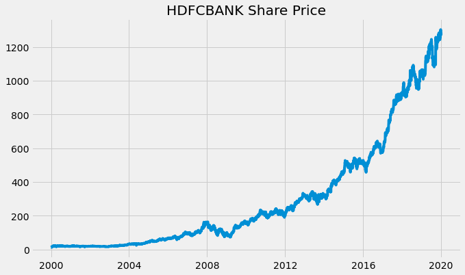

```python
# Plot share price
plt.title('HDFCBANK Share Price')
plt.plot(df1['Close'])
plt.show()
```

```python
# Calculcate scaled volume and range
df2 = df1.copy(deep=True)
df2['ATR'] = ATR(df2, 20)
df2['Svolume'] = df2['Volume'] / df2['Volume'].rolling(20).mean()
df2['Range'] = (df2['High'] - df2['Low']) / df2['ATR']

# Calculate open-to-open returns
df2['Return'] = df2.Open.shift(-2) - df2.Open.shift(-1)
# Initial target with zeros
df2['Target'] = 0

# Drop nan values
df2.dropna(inplace=True)

# Verify last 5 values
df2.tail()
```

| Date | Open | High | Low | Close | Volume | ATR | Svolume | Range | Return | Target |
| --- | --- | --- | --- | --- | --- | --- | --- | --- | --- | --- |
| 2019-12-20 | 1288.750000 | 1299.599976 | 1280.050049 | 1296.699951 | 7513022 | 18.105011 | 1.300683 | 1.079808 | -0.400024 | 0 |
| 2019-12-23 | 1299.000000 | 1304.000000 | 1288.800049 | 1302.400024 | 5097891 | 18.097510 | 0.873859 | 0.839892 | -8.900024 | 0 |
| 2019-12-24 | 1298.599976 | 1301.099976 | 1286.949951 | 1289.150024 | 3589604 | 18.230011 | 0.619394 | 0.776194 | -17.699951 | 0 |
| 2019-12-26 | 1289.699951 | 1291.849976 | 1264.650024 | 1270.449951 | 7474879 | 18.862506 | 1.260609 | 1.442012 | 10.000000 | 0 |
| 2019-12-27 | 1272.000000 | 1279.000000 | 1270.000000 | 1275.000000 | 3546496 | 18.260004 | 0.611702 | 0.492881 | -0.050049 | 0 |

```python
# Summary statistics
df2.describe()
```

|  | Open | High | Low | Close | Volume | ATR | Svolume | Range | Return | Target |
| --- | --- | --- | --- | --- | --- | --- | --- | --- | --- | --- |
| count | 4973.000000 | 4973.000000 | 4973.000000 | 4973.000000 | 4.973000e+03 | 4973.000000 | 4973.000000 | 4973.000000 | 4973.000000 | 4973.0 |
| mean | 295.552427 | 298.378277 | 292.507196 | 295.545921 | 5.044294e+06 | 6.084686 | 1.011266 | 0.975901 | 0.253728 | 0.0 |
| std | 331.704187 | 333.980017 | 329.231810 | 331.636678 | 5.623232e+06 | 5.376945 | 0.635901 | 0.518950 | 5.733890 | 0.0 |
| min | 16.595954 | 16.846206 | 15.928429 | 16.508141 | 0.000000e+00 | 0.221499 | 0.000000 | 0.000000 | -49.580805 | 0.0 |
| 25% | 38.534120 | 38.937846 | 38.063088 | 38.395046 | 1.966720e+06 | 1.420578 | 0.641659 | 0.664143 | -1.364275 | 0.0 |
| 50% | 156.791838 | 159.316738 | 154.936312 | 157.277176 | 3.729360e+06 | 5.109925 | 0.886897 | 0.879604 | 0.026345 | 0.0 |
| 75% | 452.751072 | 454.967362 | 447.595692 | 453.570129 | 6.347944e+06 | 8.468243 | 1.221241 | 1.161765 | 1.755727 | 0.0 |
| max | 1305.000000 | 1305.500000 | 1288.800049 | 1302.400024 | 2.011300e+08 | 36.948749 | 15.269140 | 7.599542 | 151.550049 | 0.0 |

### Split Data

```python
# Split the data from 2015
df_train = df2[df2.index <= datetime(2015,1,1)]
df_test  = df2[df2.index > datetime(2015,1,1)]
```

### Specify Features

```python
# Define train and test with two features
X_train = df_train[['Svolume', 'Range']]
X_test = df_test[['Svolume', 'Range']]
```

### Model Training

```python
# Training with 3 clusters
kmeans = KMeans(n_clusters=3).fit(X_train)
df_train['Target']  = kmeans.predict(X_train)
```

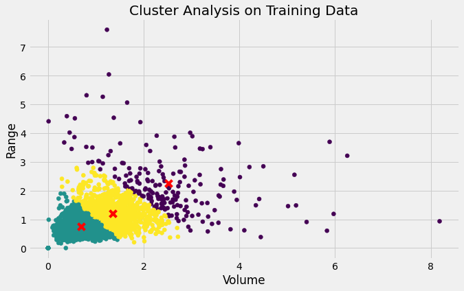

```python
# Train plot
centers = kmeans.cluster_centers_
plt.scatter(X_train['Svolume'], X_train['Range'], c=df_train['Target'])
plt.scatter(centers[:,0], centers[:,1], c='red', s=100, marker='x')
plt.xlabel('Volume')
plt.ylabel('Range')
plt.title('Cluster Analysis on Training Data')
plt.show()
```

```python
# Centroid for first feature
centers[:,0]
```

```
array([2.52040876, 0.68991141, 1.35225094])
```

```python
# Centroid for second feature
centers[:,1]
```

```
array([2.26050915, 0.73854431, 1.20488705])
```

### Testing

```python
# Testing : Assign to df_train dataframe
df_test['Target']  = kmeans.predict(X_test)
```

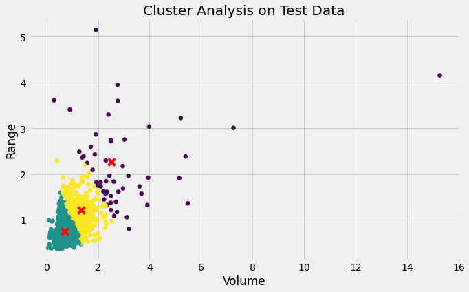

```python
# Test plot
centers = kmeans.cluster_centers_
plt.scatter(X_test['Svolume'], X_test['Range'], c=df_test['Target'])
plt.scatter(centers[:,0],centers[:,1], c='red', s=100, marker='x')
plt.xlabel('Volume')
plt.ylabel('Range')
plt.title('Cluster Analysis on Test Data')
plt.show()
```

```python
# Centroid for first feature
centers[:,0]
```

```
array([2.52040876, 0.68991141, 1.35225094])
```

```python
# Centroid for second feature
centers[:,1]
```

```
array([2.26050915, 0.73854431, 1.20488705])
```

We can see there are three distinct clusters and there is a clear relationship between higher volume and higher volatility (range). These clusters and centroids appear relatively stable in our test data set.

```python
# Output the results
print("Total Points Earned by Cluster Prediction: Training & Testing")
print(f'Cluster 1 Train: {df_train.Return.loc[df_train.Target==0].sum():0.4f} | Cluster 1 Test: {df_test.Return.loc[df_test.Target==0].sum():0.4f}')
print(f'Cluster 2 Train: {df_train.Return.loc[df_train.Target==1].sum():0.4f} | Cluster 2 Test: {df_test.Return.loc[df_test.Target==1].sum():0.4f}')
print(f'Cluster 3 Train: {df_train.Return.loc[df_train.Target==2].sum():0.4f} | Cluster 3 Test: {df_test.Return.loc[df_test.Target==2].sum():0.4f}')
```

```
Total Points Earned by Cluster Prediction: Training & Testing
Cluster 1 Train: 55.5507 | Cluster 1 Test: 13.8575
Cluster 2 Train: 315.3972 | Cluster 2 Test: 503.6686
Cluster 3 Train: 76.2431 | Cluster 3 Test: 297.0741
```

### Performance

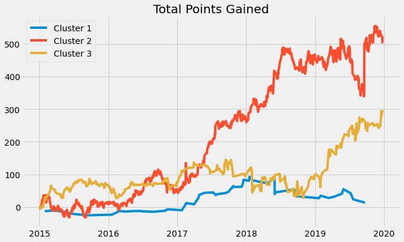

```python
# Performance plot
plt.plot(np.cumsum(df_test['Return'].loc[df_test['Target'] == 0]),label='Cluster 1')
plt.plot(np.cumsum(df_test['Return'].loc[df_test['Target'] == 1]),label='Cluster 2')
plt.plot(np.cumsum(df_test['Return'].loc[df_test['Target'] == 2]),label='Cluster 3')
plt.title('Total Points Gained')
plt.legend()
plt.show()
```

# References

- [KMeans](https://scikit-learn.org/stable/modules/generated/sklearn.cluster.KMeans.html)
- [Silhouette Score](https://scikit-learn.org/stable/modules/generated/sklearn.metrics.silhouette_score.html)
- [Python Resources](https://github.com/kannansingaravelu/PythonResources)

[Kannan Singaravelu](https://github.com/kannansingaravelu)  
Certificate in Quantitative Finance, June 2021